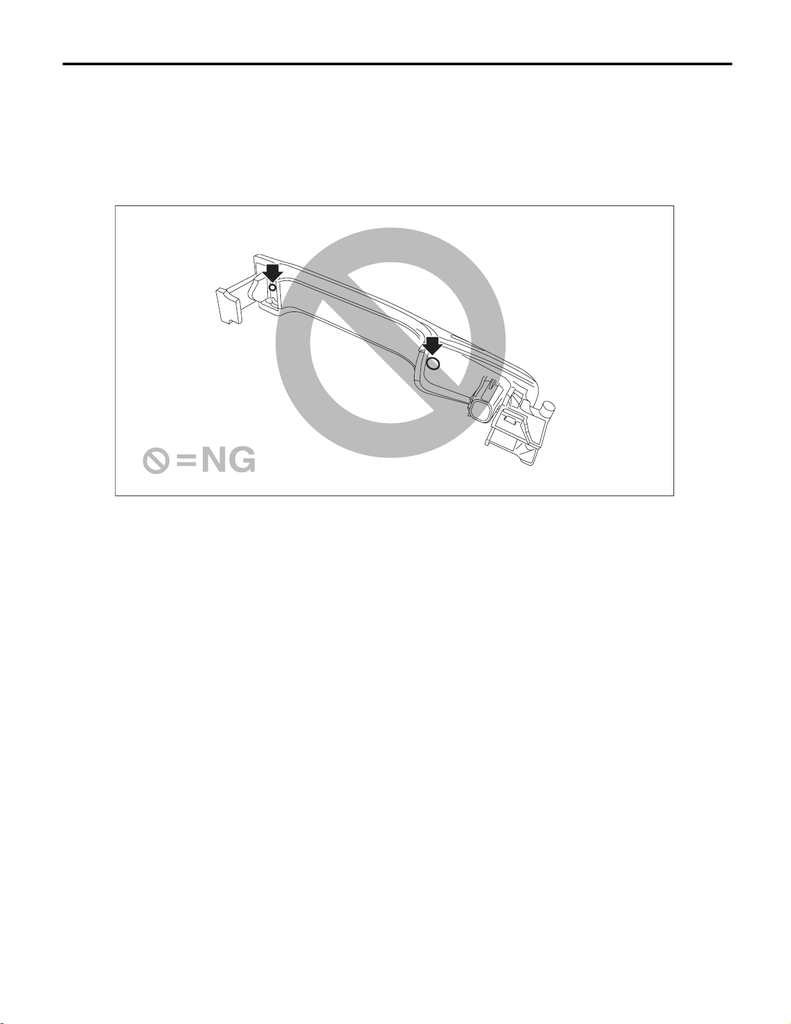

SL-95

Keyless Access Outdoor Antenna

SECURITY AND LOCKS

30.Keyless Access Outdoor Antenna

A: REMOVAL

1. FRONT ANTENNA

CAUTION:

Do not detach the antenna from the front door outer handle.

If replacement is required, replace the front outer handle assembly as a whole.

1) Disconnect the ground cable from battery. <Ref. to NT-5, BATTERY, NOTE, Note.>

NOTE:

For models other than STI model, disconnect the ground terminal from battery sensor.

2) Remove the handle - door outer. <Ref. to SL-33, REMOVAL, Front Outer Handle.>

SL-01600

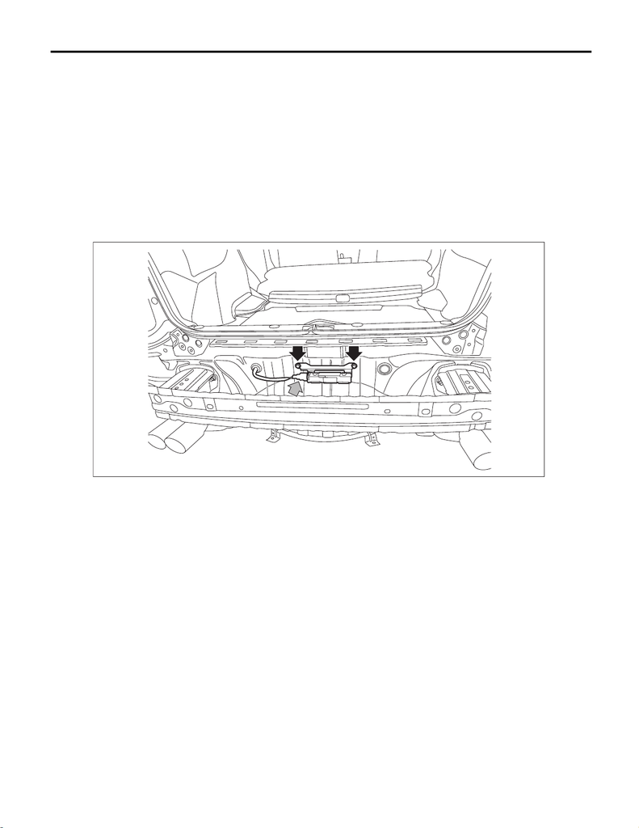

SL-96

Keyless Access Outdoor Antenna

SECURITY AND LOCKS

2. REAR ANTENNA

CAUTION:

• Do not detach the antenna except when replacing it. Detaching unnecessarily will lead to insecure

attachment of the antenna.

• When replacing the antenna, do not reuse the tapping screw. Always replace with new tapping

screws.

1) Disconnect the ground cable from battery. <Ref. to NT-5, BATTERY, NOTE, Note.>

NOTE:

For models other than STI model, disconnect the ground terminal from battery sensor.

2) Remove the bumper face - rear. <Ref. to EI-41, REMOVAL, Rear Bumper.>

3) Remove the rear antenna assembly - exterior.

(1) Disconnect the connector.

(2) Remove the screws, and remove the rear antenna assembly - exterior.

B: INSTALLATION

1) Install the rear antenna assembly - exterior.

Tightening torque:

7.5 N·m (0.8 kgf-m, 5.5 ft-lb)

2) Install the bumper face - rear.

3) Connect the battery ground terminal. <Ref. to NT-5, BATTERY, NOTE, Note.>

NOTE:

For models other than STI model, connect the ground terminal to battery sensor.

C: INSPECTION

1) Check the setting by performing Keyless access system check using the Subaru Select Monitor. <Ref. to

KPS(diag)-38, OPERATION, Keyless Access System Check.>

2) Disconnect the Subaru Select Monitor. Operate the touch sensor of the door outer handle to check if door

lock operates.

3) If the system does not operate normally as the result of inspection, refer to “General Diagnostic Table” of

the “KEYLESS ACCESS WITH PUSH BUTTON START SYSTEM (DIAGNOSTICS)” section. <Ref. to

KPS(diag)-111, KEYLESS ACCESS SYSTEM, INSPECTION, General Diagnostic Table.>

SL-02879